# Reproducible Research: Peer Assessment 1

## **Loading and preprocessing the data**

### Load the data

Read data with NA’s

```r
if(!file.exists("activity.csv")) {
    unzip("activity.zip")
}
data_wna <- read.csv("./activity.csv")
```

### Preprocessing data

I removed the rows containing NA’s.

```r
data <- na.omit(data_wna)
```

## **What is mean total number of steps taken per day?**

```r
library(dplyr)
```

### Calculate the total number of steps taken per day

```r
nStepsDay <- data %>%
    group_by(date) %>%
    summarise(totalsteps = sum(steps)) %>%
    as.data.frame()

nStepsDay
```

```
##          date totalsteps
## 1  2012-10-02        126
## 2  2012-10-03      11352
## 3  2012-10-04      12116
## 4  2012-10-05      13294
## 5  2012-10-06      15420
## 6  2012-10-07      11015
## 7  2012-10-09      12811
## 8  2012-10-10       9900
## 9  2012-10-11      10304
## 10 2012-10-12      17382
## 11 2012-10-13      12426
## 12 2012-10-14      15098
## 13 2012-10-15      10139
## 14 2012-10-16      15084
```

[output cut: 39 more lines]

### Make a histogram of the total number of steps taken per day

```r
library(ggplot2)
```

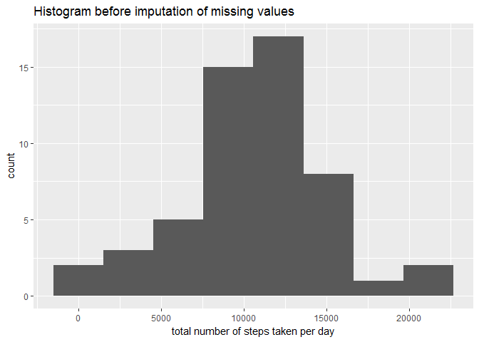

```r
ggplot(nStepsDay, aes(x = totalsteps)) +
    geom_histogram(bins = 8) +
    ggtitle("Histogram before imputation of missing values") +
    xlab("total number of steps taken per day")
```

### Calculate and report the mean and median of the total number of steps taken per day

```r
summary <- nStepsDay %>%
    summarise(mean = mean(totalsteps),
              median = median(totalsteps)) %>%
    as.data.frame()

summary
```

```
##       mean median
## 1 10766.19  10765
```

Hence the `mean` is **10766** steps and the `median` is **10765** steps.

## **What is the average daily activity pattern?**

### Make a time series plot (i.e. type = “l”) of the 5 minute interval (x-axis) and the average number of steps taken, averaged across all days (y-axis)

```r
# divide oberservations in groups of intervals and apply the mean to each group
stepIntervalMean <- aggregate(steps ~ interval, data, mean)
```

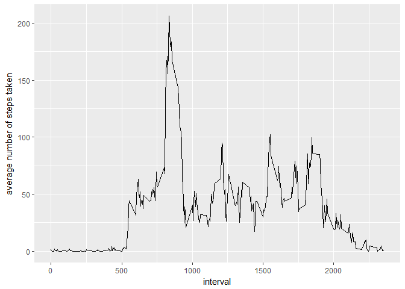

```r
ggplot(stepIntervalMean, aes(x = interval, y = steps)) +
    geom_line() +
    ylab("average number of steps taken")
```

```r
# calculation of 5-minute interval where steps is maximum across all days on average
stepIntervalMean$interval[which.max(stepIntervalMean$steps)]
```

```
## [1] 835
```

Hence, the `interval` is **835**. In different notation this would be 8:35 AM.

## **Imputing missing values**

### Calculate and report the total number of missing values in the dataset (i.e. the total number of rows with NA’s)

```r
sum(!complete.cases(data_wna))
```

```
## [1] 2304
```

There are **2304** missing values in the dataset.

### Strategy for filling in all of the missing values in the data set

I replaced missing values in the dataset with the mean for that 5-minute interval.

### Create a new dataset that is equal to the original dataset but with the missing data filled in

```r
data_new <- data_wna

data_new$steps[which(is.na(data_new$steps))] <- stepIntervalMean$steps
```

### Make a histogram of the total number of steps taken per day

```r
nStepsDay_imp <- data_new %>%
    group_by(date) %>%
    summarise(totalsteps = sum(steps)) %>%
    as.data.frame()
```

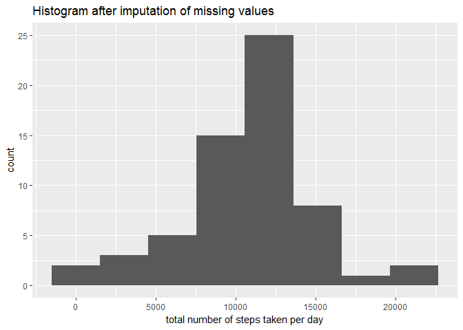

```r
ggplot(nStepsDay_imp, aes(x = totalsteps)) +
    geom_histogram(bins = 8) +
    ggtitle("Histogram after imputation of missing values") +
    xlab("total number of steps taken per day")
```

### Calculate and report the mean and median of the total number of steps taken per day

```r
summary_imp <- nStepsDay_imp %>%
    summarise(mean = mean(totalsteps),
              median = median(totalsteps)) %>%
    as.data.frame()

summary_imp
```

```
##       mean   median
## 1 10766.19 10766.19
```

Hence the `mean` is **10766** steps and the `median` is **10766** steps.

### Do these values differ from the estimates from the first part of the assignment?

Yes, the median differs slightly from each other.

- before imputation `mean` was **10766** steps and the `median` was **10765** steps.
- after imputation `mean` is **10766** steps and the `median` is **10766** steps.

### What is the impact of imputing missing data on estimates of the total daily number of steps?

Observations:

- The impact of the imputation is that the `median` moved closer to the `mean`. More strongly, they are now equal.
- The impact of the imputation is that the count (amount of days) has increased from 17 to 25.

## **Are there differences in activity patterns between weekdays and weekends?**

### Create a new factor variable in the dataset with two levels indicating whether a given date is a weekday or weekend day

First we need to convert the date from factor into a date, before we can apply the `weekdays()` function.

```r
data_new$date <- as.Date(as.character(data_new$date, format = "%Y-%m-$d"))
```

Next, we create a factor variable with levels “weekend” and “weekday”.

```r
weekdays <- weekdays(data_new$date)

data_new$day_type <- ifelse(weekdays %in% c("Saturday", "Sunday"), "weekend", "weekday")

# convert to factor
data_new$day_type <- as.factor(data_new$day_type)
```

### Make a panel plot containing a time series plot of the 5-minute interval (x-axis) and the average number of steps taken, averaged across all weekday days or weekend days (y-axis).

```r
# divide oberservations in groups of intervals and apply the mean to each group
stepIntervalMean_imp <- aggregate(steps ~ interval+day_type, data_new, mean)
```

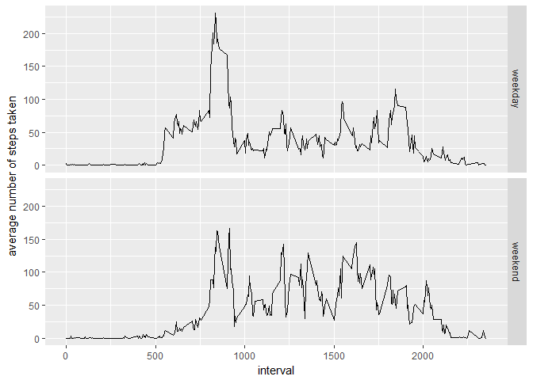

```r
p <- ggplot(stepIntervalMean_imp, aes(x = interval, y = steps))
p + geom_line() + facet_grid(day_type ~ .) + ylab("average number of steps taken")
```